# Application 2

Author

Martin Hsu

# Markov Chains

**Every day for lunch you have either a sandwich (state 1), a burrito (state 2), or pizza (state 3). Suppose your lunch choices from one day to the next follow a Markov chain with transition matrix**

$$\textbf{P} = \begin{bmatrix}
0 & 0.5 & 0.5 \\
0.1 & 0.4 & 0.5 \\
0.2 & 0.3 & 0.5
\end{bmatrix}$$

**Suppose today is Monday and consider your upcoming lunches.**

- **Monday is day 0, Tuesday is day 1, etc.**
- **You start with pizza on day 0 (Monday).**
- **Let $T$ be the first time (day) you have a sandwich. (Note: it is possible for $T$ to be greater than 4.)**
- **Let $V$ be the number of times (days) you have a burrito this five-day work week.**
- **Pizza costs $5, burrito $7, and sandwich $9.**
- **Let $X_n$ be the cost of your lunch on day $n$.**
- **Let $W=X_0+\cdots+X_4$ be your total lunch cost for this five-day work week.**

**Write code to setup and run a simulation to investigate the following.**

## Setup

```r
library(tidyverse)
library(ggthemes)
library(viridis)
library(prismatic)
```

```r
# Set seed for consistent results
set.seed(123)
```

## 1)

**Approximate the marginal distribution, along with the expected value and standard deviation, of each of the following:**

### 1) $X_4$

First, let’s simulate one sample path, AKA one 5-day work week of pizzas, burritos and sandwiches:

```r
# Define state space
state_names <- c(9, 7, 5)
# Define transition matrix
P <- rbind(
  c(0, 0.5, 0.5),
  c(0.1, 0.4, 0.5),
  c(0.2, 0.3, 0.5)
)
# Name the entries of the transition matrix
colnames(P) <- state_names
rownames(P) <- state_names
# Print transition matrix
as.data.frame(P)
```

|  | 9 | 7 | 5 |
| --- | --- | --- | --- |
| 9 | 0.0 | 0.5 | 0.5 |
| 7 | 0.1 | 0.4 | 0.5 |
| 5 | 0.2 | 0.3 | 0.5 |

```r
# Set path length
n <- 5
# Set starting distribution
pi_0 <- c(0, 0, 1)
# Simulate a path
path <- numeric(n)
# First select starting state based on starting distribution
path[[1]] <- sample(state_names, 1, prob = pi_0)
# Then until we reach nth entry, we select next state based on transition matrix
for (i in 2:n) {
  path[[i]] <- sample(state_names, 1, prob = P[as.character(path[[i-1]]),])
}
# Print path
path
```

```
[1] 5 7 5 9 5
```

Now, let’s do this multiple times to create a sample of paths:

```r
# Turn our one-path simulation code into a function
lunch_path <- function(P, state_names, pi_0, n) {
  path <- numeric(n)
  path[[1]] <- sample(state_names, 1, prob = pi_0)
  for (i in 2:n) {
    path[[i]] <- sample(state_names, 1, prob = P[as.character(path[[i-1]]),])
  }
  return(path)
}
```

```r
# Specify number of sample paths
reps <- 10000
# Initialize list of paths
samp <- NULL
# Create paths
for (i in 1:reps) {
  samp <- rbind(samp, lunch_path(P, state_names, pi_0, n))
}
# Name Xn's
colnames(samp) <- c("X0", "X1", "X2", "X3", "X4")
samp <- as.data.frame(samp)

# Print some sample paths
head(samp)
```

|  | X0 | X1 | X2 | X3 | X4 |
| --- | --- | --- | --- | --- | --- |
| 1 | 5 | 7 | 7 | 7 | 5 |
| 2 | 5 | 5 | 7 | 7 | 5 |
| 3 | 5 | 5 | 5 | 5 | 9 |
| 4 | 5 | 7 | 7 | 9 | 5 |
| 5 | 5 | 7 | 7 | 5 | 5 |
| 6 | 5 | 9 | 5 | 7 | 5 |

Now, we can approximate each of the sample statistics for each of the random variables, starting with $X_4$.

Let’s define a few helper functions to do that:

```r
marginal_dist <- function(sample_paths, var) {
  # Get density for each unique value of var
  dist <- sample_paths %>%
    group_by({{ var }}) %>%
    summarise(P = n() / nrow(sample_paths))
  return(dist)
}
```

```r
plot_marginal_dist <- function(sample_paths, var) {
  # Get variable name as string - for our graph labels
  varname <- deparse(substitute(var))
  # Plot histogram of marginal distribution
  sample_paths %>%
    ggplot(mapping=aes({{ var }})) +
    geom_histogram(aes(y = ..count.. / sum(..count..))) +
    labs(title = paste("Simulated Marginal Distribution of", varname, "with", nrow(sample_paths), "Paths"),
         x = varname,
         y = "Density") +
    theme_bw() +
    theme(panel.grid.major = element_blank(),
          panel.grid.minor = element_blank())
}
```

Marginal Distribution:

```r
marginal_dist(samp, X4)
```

| X4 | P |
| --- | --- |
| 5 | 0.5071 |
| 7 | 0.3580 |
| 9 | 0.1349 |

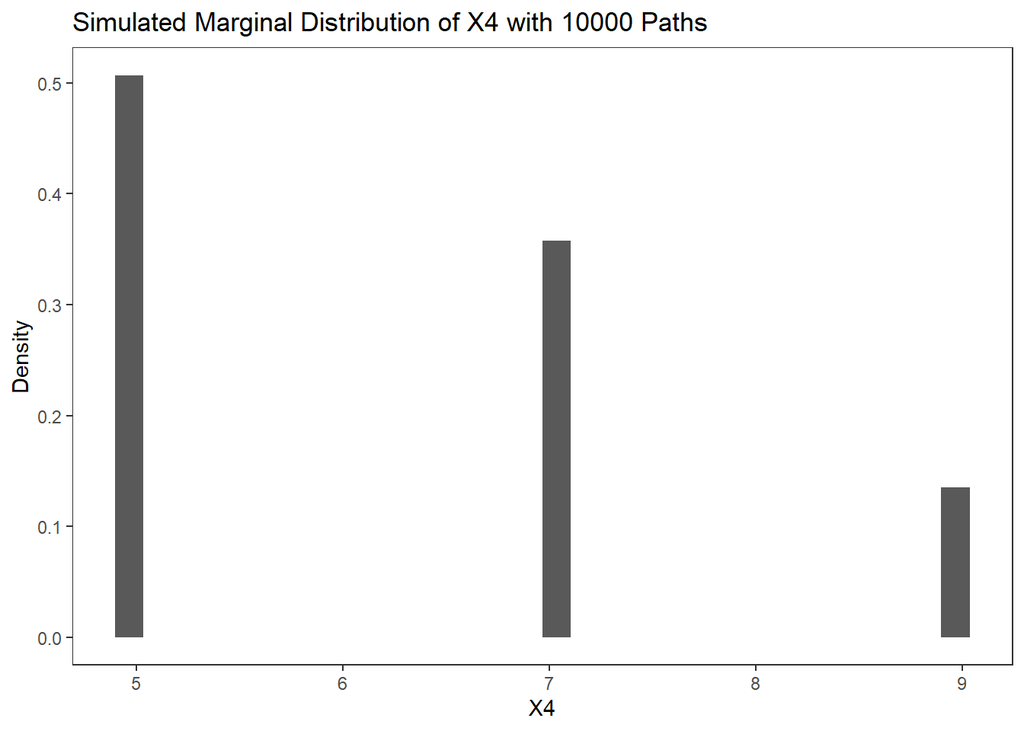

```r
plot_marginal_dist(samp, X4)
```

> This distribution appears to be discrete, with 5 being the most likely value, followed by 7, then 9. We can describe this distribution as right-skewed with a range of $[5, 9]$. From this distribution, we can infer that on Friday, I am most likely to buy a pizza, and least likely to buy a sandwich.

Expected Value:

```r
mean(samp$X4)
```

```
[1] 6.2556
```

Standard Deviation:

```r
sd(samp$X4)
```

```
[1] 1.419179
```

### 2) $T$

Because T (first sandwich encounter) can be greater than 4, we need to make a special simulation. (All other variables can rely on our $X_4$ simulation.) We need paths that go beyond 5 steps, at least until we encounter our first sandwich. As a result, rather than stopping at $X_4$, this new simulation only terminates a path when we finally encounters a sandwich (which is coded by its cost of $9), or when we reach $X_4$, whichever happens last.

```r
lunch_path_t <- function(P, state_names, pi_0, terminal_state) {
  # Get initial state
  state <- sample(state_names, 1, prob = pi_0)
  # Initialize index for while loop
  i <- 2
  # Initialize path
  path <- numeric()
  # Set path starting state
  path[[1]] <- state
  # Keep generating new states in the path until we encounter terminal state
  while (!(state == terminal_state)) {
    state <- sample(state_names, 1, prob = P[as.character(path[[i-1]]),])
    path[[i]] <- state
    # Remember to increment
    i = i + 1
  }
  # If there is less than 6 steps, bring it up to 6
  while (i <= 6) {
    state <- sample(state_names, 1, prob = P[as.character(path[[i-1]]),])
    path[[i]] <- state
    # Remember to increment
    i = i + 1
  }
  return(path)
}
```

Here is an example path:

```r
samp_path_t <- lunch_path_t(P, state_names, pi_0, 9)
samp_path_t
```

```
[1] 5 7 7 7 5 5 9
```

We are only interested in the first occurrence of a sandwich.

```r
min(which(samp_path_t == 9)) - 1
```

```
[1] 6
```

Now, let’s do this multiple times to get a sample of T. We also want to include $X_0$ thru $X_5$ in order to let us plot joint distributions later on.

```r
# Initialize list of T values
T_samp <- NULL
# Create paths
for (i in 1:reps) {
  tpath <- lunch_path_t(P, state_names, pi_0, 9)
  T_samp <- rbind(T_samp,
                  c(tpath[[1]], tpath[[2]], tpath[[3]], tpath[[4]], tpath[[5]], tpath[[6]],
                    min(which(tpath == 9)) - 1))
}
colnames(T_samp) <- c("X0", "X1", "X2", "X3", "X4", "X5", "T")
T_samp <- as.data.frame(T_samp)

# Print some sample T
head(T_samp)
```

|  | X0 | X1 | X2 | X3 | X4 | X5 | T |
| --- | --- | --- | --- | --- | --- | --- | --- |
| 1 | 5 | 7 | 5 | 5 | 9 | 5 | 4 |
| 2 | 5 | 5 | 7 | 7 | 7 | 5 | 8 |
| 3 | 5 | 5 | 5 | 7 | 7 | 5 | 7 |
| 4 | 5 | 5 | 9 | 5 | 5 | 5 | 2 |
| 5 | 5 | 7 | 9 | 5 | 7 | 5 | 2 |
| 6 | 5 | 7 | 5 | 9 | 5 | 5 | 3 |

Now, we can approximate each of the sample statistics for $T$.

Marginal Distribution:

```r
marginal_dist(T_samp, `T`)
```

| T | P |
| --- | --- |
| 1 | 0.1994 |
| 2 | 0.1281 |
| 3 | 0.1034 |
| 4 | 0.0936 |
| 5 | 0.0769 |
| 6 | 0.0637 |
| 7 | 0.0584 |
| 8 | 0.0461 |
| 9 | 0.0400 |
| 10 | 0.0302 |

[output cut: 35 more lines]

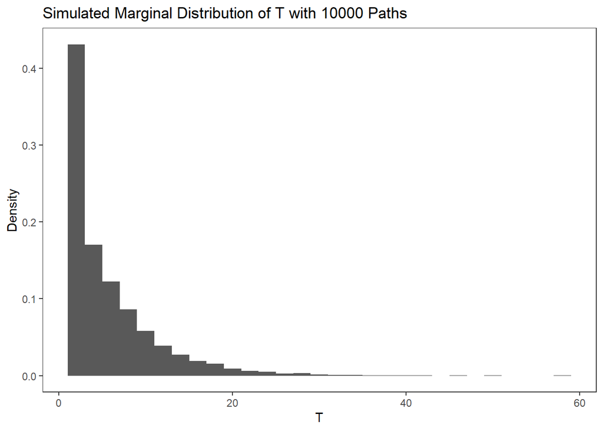

```r
plot_marginal_dist(T_samp, `T`)
```

Expected Value:

```r
mean(T_samp$`T`)
```

```
[1] 5.9199
```

Standard Deviation:

```r
sd(T_samp$`T`)
```

```
[1] 5.533782
```

### 3) $V$

We first must calculate $V$ for each path.

```r
V_samp <- samp %>%
  mutate(V = (X0 == 7) + (X1 == 7) + (X2 == 7) + (X3 == 7) + (X4 == 7))

head(V_samp)
```

|  | X0 | X1 | X2 | X3 | X4 | V |
| --- | --- | --- | --- | --- | --- | --- |
| 1 | 5 | 7 | 7 | 7 | 5 | 3 |
| 2 | 5 | 5 | 7 | 7 | 5 | 2 |
| 3 | 5 | 5 | 5 | 5 | 9 | 0 |
| 4 | 5 | 7 | 7 | 9 | 5 | 2 |
| 5 | 5 | 7 | 7 | 5 | 5 | 2 |
| 6 | 5 | 9 | 5 | 7 | 5 | 1 |

Now we can approximate each of the sample statistics for $V$.

Marginal Distribution:

```r
marginal_dist(V_samp, V)
```

| V | P |
| --- | --- |
| 0 | 0.1934 |
| 1 | 0.3773 |
| 2 | 0.2981 |
| 3 | 0.1139 |
| 4 | 0.0173 |

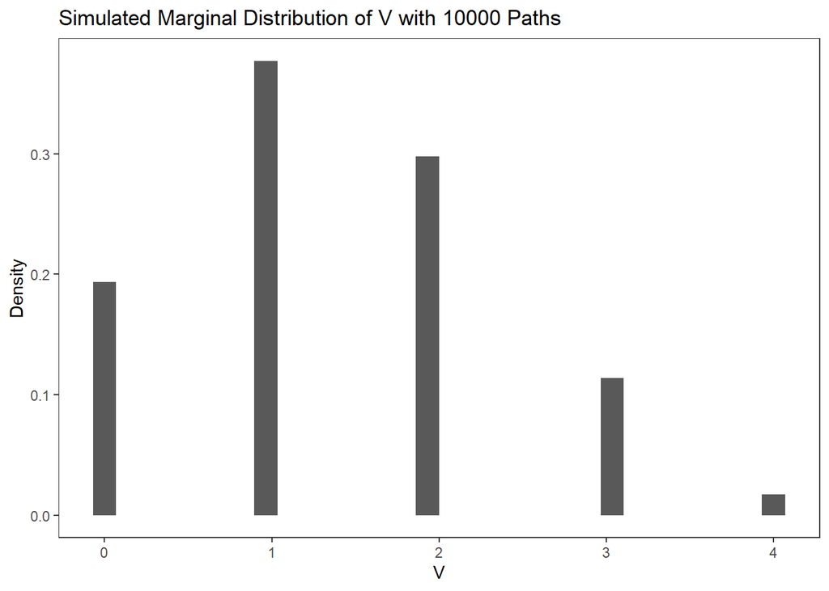

```r
plot_marginal_dist(V_samp, V)
```

> This distribution appears to be discrete, with 1 being the most likely value, and 4 being the least likely. We can describe this distribution as moderately right-skewed with a range of $[0, 4]$, which makes sense given that there are only days 0-4. This resembles a binomial distribution with a parameter $p<0.5$.

Expected Value:

```r
mean(V_samp$V)
```

```
[1] 1.3844
```

Standard Deviation:

```r
sd(V_samp$V)
```

```
[1] 0.9773086
```

### 3) $W$

We first must calculate $W$ for each path.

```r
W_samp <- samp %>%
  mutate(W = X0 + X1 + X2 + X3 + X4)

head(W_samp)
```

|  | X0 | X1 | X2 | X3 | X4 | W |
| --- | --- | --- | --- | --- | --- | --- |
| 1 | 5 | 7 | 7 | 7 | 5 | 31 |
| 2 | 5 | 5 | 7 | 7 | 5 | 29 |
| 3 | 5 | 5 | 5 | 5 | 9 | 29 |
| 4 | 5 | 7 | 7 | 9 | 5 | 33 |
| 5 | 5 | 7 | 7 | 5 | 5 | 29 |
| 6 | 5 | 9 | 5 | 7 | 5 | 31 |

Now we can approximate each of the sample statistics for $V$.

Marginal Distribution:

```r
marginal_dist(W_samp, W)
```

| W | P |
| --- | --- |
| 25 | 0.0662 |
| 27 | 0.1524 |
| 29 | 0.2623 |
| 31 | 0.2725 |
| 33 | 0.1703 |
| 35 | 0.0663 |
| 37 | 0.0100 |

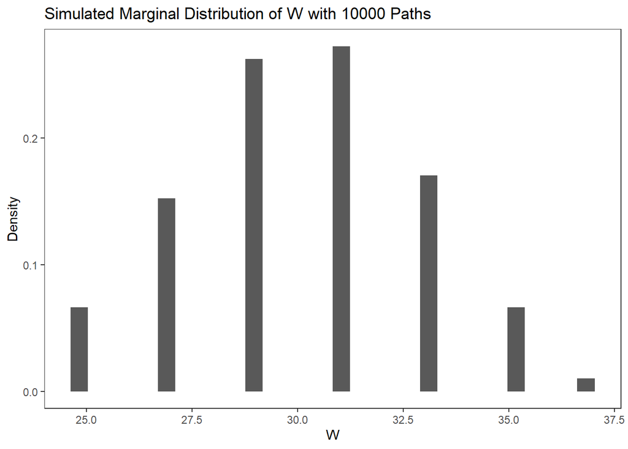

```r
plot_marginal_dist(W_samp, W)
```

> This distribution appears to be discrete, with 31 being the most likely value and 37 being the least likely. This distribution is almost symmetric, with a slight right skew and a range of 7 values in $[25, 37]$, which seems to be the all possible values of $W$. It is centered around $31.

Expected Value:

```r
mean(W_samp$W)
```

```
[1] 30.1344
```

Standard Deviation:

```r
sd(W_samp$W)
```

```
[1] 2.687798
```

## 3)

**Approximate the joint distribution, along with the correlation, of each of the following:**

## $X_4$ and $X_5$

For the sake of simplicity, let’s calculate all our random variables based off the simulation generated from finding the distribution of $T$, and use this to approximate our joint distributions.

```r
samp_all <- T_samp %>%
  mutate(V = (X0 == 7) + (X1 == 7) + (X2 == 7) + (X3 == 7) + (X4 == 7),
         W = X0 + X1 + X2 + X3 + X4)

head(samp_all)
```

|  | X0 | X1 | X2 | X3 | X4 | X5 | T | V | W |
| --- | --- | --- | --- | --- | --- | --- | --- | --- | --- |
| 1 | 5 | 7 | 5 | 5 | 9 | 5 | 4 | 1 | 31 |
| 2 | 5 | 5 | 7 | 7 | 7 | 5 | 8 | 3 | 31 |
| 3 | 5 | 5 | 5 | 7 | 7 | 5 | 7 | 2 | 29 |
| 4 | 5 | 5 | 9 | 5 | 5 | 5 | 2 | 0 | 29 |
| 5 | 5 | 7 | 9 | 5 | 7 | 5 | 2 | 2 | 33 |
| 6 | 5 | 7 | 5 | 9 | 5 | 5 | 3 | 1 | 31 |

Now let’s approximate each of our joint distributions, starting with $X_4$ and $X_5$.

Let’s define a few helper functions to do that:

```r
joint_dist <- function(sample_paths, var1, var2) {
  # Get crosstab of frequencies
  ctab <- sample_paths %>%
    group_by({{ var1 }}, {{ var2 }}) %>%
    summarise(p = n()) %>%
    pivot_wider(names_from = {{ var2 }},
                values_from = p,
                values_fill = 0) %>%
    as.matrix()
  # Name rows
  rownames(ctab) <- ctab[,1]
  # Normalize
  ctab <- as.data.frame(ctab[, -1] / nrow(sample_paths))
  return(ctab)
}
```

```r
plot_joint_dist <- function(sample_paths, var1, var2) {
  varname1 <- deparse(substitute(var1))
  varname2 <- deparse(substitute(var2))
  xbins <- sample_paths %>%
    distinct({{ var2 }}) %>%
    count() %>%
    pull
  ybins <- sample_paths %>%
    distinct({{ var1 }}) %>%
    count() %>%
    pull

  sample_paths %>%
    ggplot(mapping = aes(x = {{ var2 }},
                         y = {{ var1 }},
                         fill = ..count.. / sum(..count..))) +
    geom_bin2d(bins = c(min(xbins, 30), min(ybins, 30))) +
    scale_fill_continuous(type = "viridis") +
    labs(x = varname2,
         y = varname1,
         title = paste("Simulated Joint Distribution of", varname1, "and", varname2, "with", nrow(sample_paths), "Paths"),
         fill = "Density") +
    theme_bw() +
    theme(panel.grid.major = element_blank(),
          panel.grid.minor = element_blank())
}
```

Joint Distribution:

```r
joint_dist(samp_all, X4, X5)
```

|  | 5 | 7 | 9 |
| --- | --- | --- | --- |
| 5 | 0.2525 | 0.1468 | 0.0988 |
| 7 | 0.1778 | 0.1450 | 0.0385 |
| 9 | 0.0726 | 0.0680 | 0.0000 |

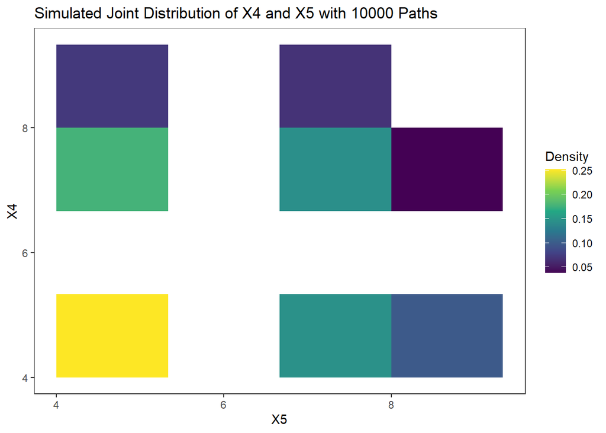

```r
plot_joint_dist(samp_all, X4, X5)
```

Correlation:

```r
cor(samp_all$X4, samp_all$X5)
```

```
[1] -0.09750535
```

### 2) $T$ and $V$

Joint Distribution:

```r
joint_dist(samp_all, `T`, V)
```

|  | 0 | 1 | 2 | 3 | 4 |
| --- | --- | --- | --- | --- | --- |
| 1 | 0.0457 | 0.0824 | 0.0551 | 0.0162 | 0.0000 |
| 2 | 0.0359 | 0.0527 | 0.0330 | 0.0065 | 0.0000 |
| 3 | 0.0263 | 0.0444 | 0.0279 | 0.0048 | 0.0000 |
| 4 | 0.0259 | 0.0405 | 0.0229 | 0.0043 | 0.0000 |
| 5 | 0.0129 | 0.0259 | 0.0253 | 0.0115 | 0.0013 |
| 6 | 0.0072 | 0.0206 | 0.0208 | 0.0123 | 0.0028 |
| 7 | 0.0075 | 0.0187 | 0.0193 | 0.0106 | 0.0023 |
| 8 | 0.0072 | 0.0130 | 0.0153 | 0.0087 | 0.0019 |
| 9 | 0.0042 | 0.0132 | 0.0138 | 0.0072 | 0.0016 |
| 10 | 0.0038 | 0.0091 | 0.0115 | 0.0040 | 0.0018 |

[output cut: 35 more lines]

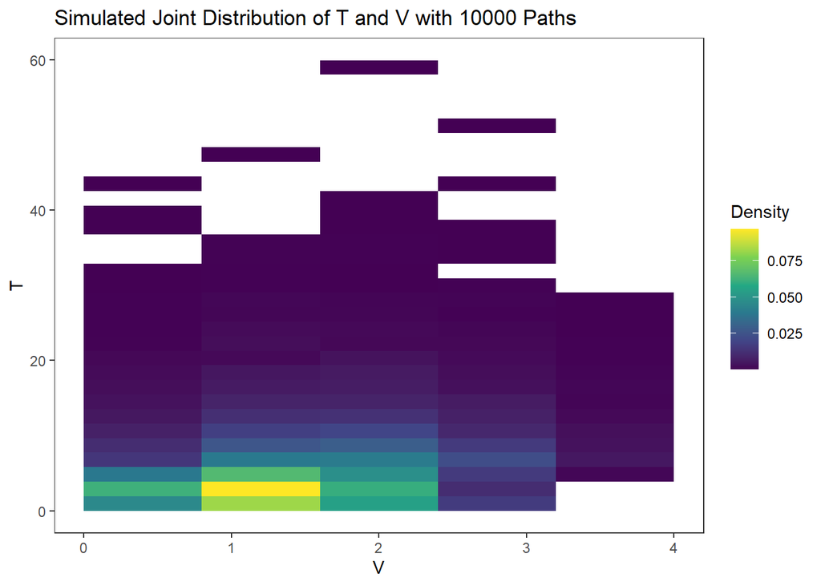

```r
plot_joint_dist(samp_all, `T`, V)
```

> This joint distribution seems to have a weak linear association, with greater density near $V=1$ and $T=0$.

Correlation:

```r
cor(samp_all$`T`, samp_all$`V`)
```

```
[1] 0.2010747
```

### 3) $T$ and $W$

Joint Distribution:

```r
joint_dist(samp_all, `T`, W)
```

|  | 29 | 31 | 33 | 35 | 37 | 25 | 27 |
| --- | --- | --- | --- | --- | --- | --- | --- |
| 1 | 0.0250 | 0.0547 | 0.0679 | 0.0439 | 0.0079 | 0.0000 | 0.0000 |
| 2 | 0.0253 | 0.0442 | 0.0420 | 0.0150 | 0.0016 | 0.0000 | 0.0000 |
| 3 | 0.0263 | 0.0444 | 0.0279 | 0.0048 | 0.0000 | 0.0000 | 0.0000 |
| 4 | 0.0259 | 0.0405 | 0.0229 | 0.0043 | 0.0000 | 0.0000 | 0.0000 |
| 5 | 0.0253 | 0.0115 | 0.0013 | 0.0000 | 0.0000 | 0.0129 | 0.0259 |
| 6 | 0.0208 | 0.0123 | 0.0028 | 0.0000 | 0.0000 | 0.0072 | 0.0206 |
| 7 | 0.0193 | 0.0106 | 0.0023 | 0.0000 | 0.0000 | 0.0075 | 0.0187 |
| 8 | 0.0153 | 0.0087 | 0.0019 | 0.0000 | 0.0000 | 0.0072 | 0.0130 |
| 9 | 0.0138 | 0.0072 | 0.0016 | 0.0000 | 0.0000 | 0.0042 | 0.0132 |
| 10 | 0.0115 | 0.0040 | 0.0018 | 0.0000 | 0.0000 | 0.0038 | 0.0091 |

[output cut: 35 more lines]

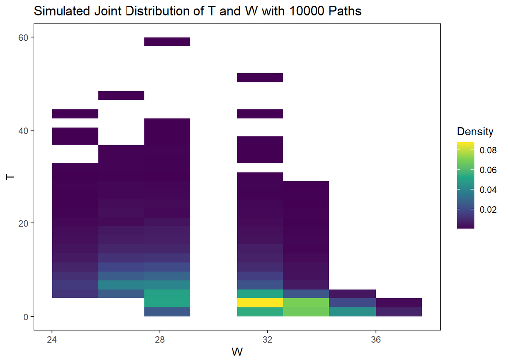

```r
plot_joint_dist(samp_all, `T`, W)
```

> This joint distribution seems to have a moderate negative linear association, with greater density near $W=32$ and $T=0$.

Correlation:

```r
cor(samp_all$`T`, samp_all$W)
```

```
[1] -0.4772602
```

### 4) $W$ and $V$

Joint Distribution:

```r
joint_dist(samp_all, W, V)
```

|  | 0 | 1 | 2 | 3 | 4 |
| --- | --- | --- | --- | --- | --- |
| 25 | 0.0635 | 0.0000 | 0.0000 | 0.0000 | 0.0000 |
| 27 | 0.0000 | 0.1505 | 0.0000 | 0.0000 | 0.0000 |
| 29 | 0.1025 | 0.0000 | 0.1577 | 0.0000 | 0.0000 |
| 31 | 0.0000 | 0.1838 | 0.0000 | 0.0856 | 0.0000 |
| 33 | 0.0313 | 0.0000 | 0.1294 | 0.0000 | 0.0182 |
| 35 | 0.0000 | 0.0362 | 0.0000 | 0.0318 | 0.0000 |
| 37 | 0.0000 | 0.0000 | 0.0095 | 0.0000 | 0.0000 |

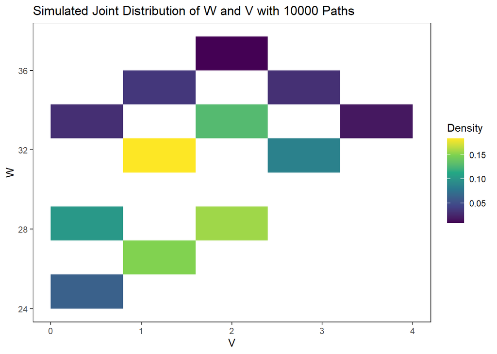

```r
plot_joint_dist(samp_all, W, V)
```

> This joint distribution seems to have a moderate positive linear association, with greater density near $W=32$ and $V=1$. There appear to be only particular values of W that are possible given V, and vice versa.

Correlation:

```r
cor(samp_all$W, samp_all$V)
```

```
[1] 0.4540172
```

## 3)

Here, I take the approach of generating repetitions until I have 10,000 repetitions where $T=4$.

```r
# Initialize list of T values
VT_samp <- NULL
# Create paths
for (i in 1:reps) {
  # First try
  tpath <- lunch_path_t(P, state_names, pi_0, 9)
  tval <- min(which(tpath == 9)) - 1
  # Retry rep until T=4
  while (tval != 4) {
    tpath <- lunch_path_t(P, state_names, pi_0, 9)
    tval <- min(which(tpath == 9)) - 1
  }
  VT_samp <- rbind(VT_samp,
                  c(tpath[[1]], tpath[[2]], tpath[[3]], tpath[[4]], tpath[[5]], tpath[[6]],
                    tval))
}
colnames(VT_samp) <- c("X0", "X1", "X2", "X3", "X4", "X5", "T")
# Get V
VT_samp <- as.data.frame(VT_samp) %>%
  mutate(V = (X0 == 7) + (X1 == 7) + (X2 == 7) + (X3 == 7) + (X4 == 7)) %>%
  select(X0, X1, X2, X3, X4, V, `T`)

# Print some sample paths
head(VT_samp)
```

|  | X0 | X1 | X2 | X3 | X4 | V | T |
| --- | --- | --- | --- | --- | --- | --- | --- |
| 1 | 5 | 7 | 5 | 5 | 9 | 1 | 4 |
| 2 | 5 | 5 | 5 | 7 | 9 | 1 | 4 |
| 3 | 5 | 5 | 7 | 5 | 9 | 1 | 4 |
| 4 | 5 | 5 | 5 | 5 | 9 | 0 | 4 |
| 5 | 5 | 5 | 5 | 5 | 9 | 0 | 4 |
| 6 | 5 | 5 | 5 | 5 | 9 | 0 | 4 |

We define some more helper functions:

```r
cond_dist <- function(sample_paths, var, cond, cond_val) {
  # Get density for each unique value of var
  dist <- sample_paths %>%
    filter({{ cond }} == cond_val)
  nreps <- nrow(dist)
  dist <- dist %>%
    group_by({{ var }}) %>%
    summarise(P = n() / nreps)
  return(dist)
}
```

```r
plot_cond_dist <- function(sample_paths, var, cond, cond_val) {
  # Get variable name as string - for our graph labels
  varname <- deparse(substitute(var))
  # Plot histogram of marginal distribution
  sample_cond <- sample_paths %>%
    filter({{ cond }} == cond_val)
  sample_cond %>%
    ggplot(mapping=aes({{ var }})) +
    geom_histogram(aes(y = ..count.. / sum(..count..))) +
    labs(title = paste("Simulated Marginal Distribution of", varname, "with", nrow(sample_cond), "Paths"),
         x = varname,
         y = "Density") +
    theme_bw() +
    theme(panel.grid.major = element_blank(),
          panel.grid.minor = element_blank())
}
```

Conditional Distribution:

```r
cond_dist(VT_samp, V, `T`, 4)
```

| V | P |
| --- | --- |
| 0 | 0.2807 |
| 1 | 0.4095 |
| 2 | 0.2573 |
| 3 | 0.0525 |

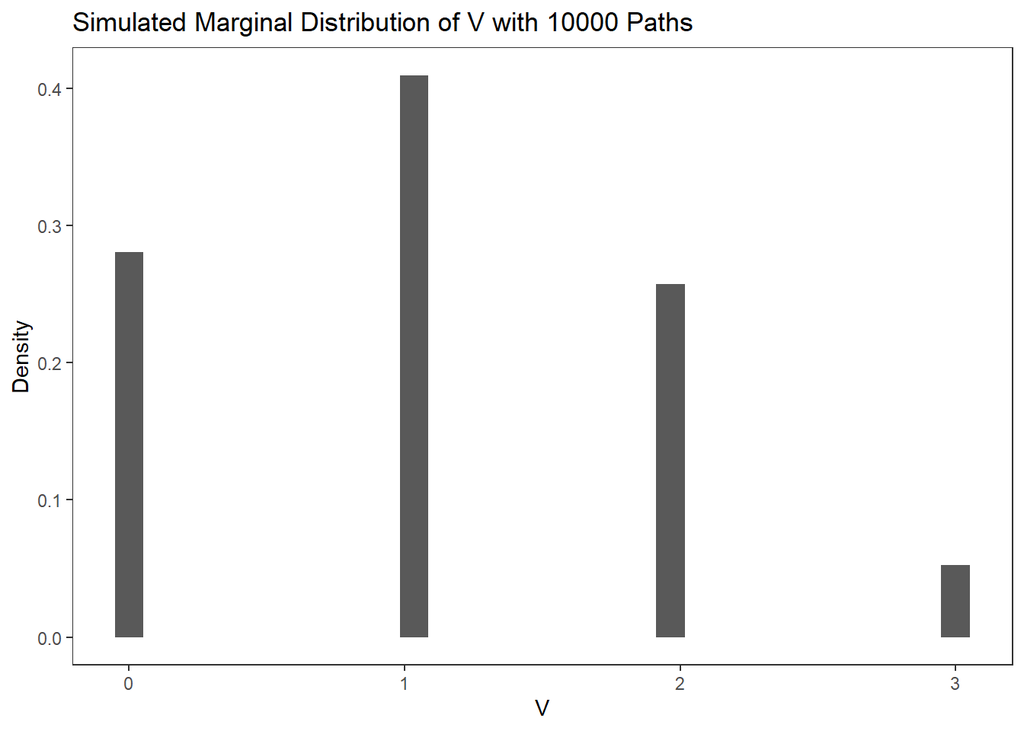

```r
plot_cond_dist(VT_samp, V, `T`, 4)
```

> Noteably, the conditional distribution of $V$ given $T=4$ has a range of $[0,3]$ instead of $[0,4]$. Although it is more symmetrical, it is still right skew. These changes indicate that $V$ may not be independent of $T$.

Conditional Mean:

```r
mean(VT_samp$V)
```

```
[1] 1.0816
```

## 4)

**Your choice. Choose at least one other joint, conditional, or marginal distribution to investigate. You can work with $X_n,T,V,W$, but you are also welcome to define other random variables in this context. You can also look at time frames other than a single week.**

Let’s define the following new variables:

- $V_1=V=$ The number of burritos we see in the first work week, $X_0,...,X_4$.
- $V_2=$ The number of burritos we see in the second work week. $X_5,...,X_9$.

We want to examine the joint distribution between these two variables.

```r
# Initialize list of paths
V2_samp <- NULL
# Create paths
for (i in 1:reps) {
  V2_samp <- rbind(V2_samp, lunch_path(P, state_names, pi_0, 10))
}
# Name Xn's
colnames(V2_samp) <- c("X0", "X1", "X2", "X3", "X4",
                    "X5", "X6", "X7", "X8", "X9")
V2_samp <- as.data.frame(V2_samp)
V2_samp <- V2_samp %>%
  mutate(V1 = (X0 == 7) + (X1 == 7) + (X2 == 7) + (X3 == 7) + (X4 == 7),
         V2 = (X5 == 7) + (X6 == 7) + (X7 == 7) + (X8 == 7) + (X9 == 7))

# Print some sample paths
head(V2_samp)
```

|  | X0 | X1 | X2 | X3 | X4 | X5 | X6 | X7 | X8 | X9 | V1 | V2 |
| --- | --- | --- | --- | --- | --- | --- | --- | --- | --- | --- | --- | --- |
| 1 | 5 | 9 | 5 | 9 | 7 | 7 | 7 | 7 | 5 | 5 | 1 | 3 |
| 2 | 5 | 5 | 5 | 9 | 5 | 9 | 5 | 7 | 7 | 5 | 0 | 2 |
| 3 | 5 | 5 | 5 | 5 | 7 | 5 | 5 | 5 | 9 | 7 | 1 | 1 |
| 4 | 5 | 5 | 5 | 7 | 7 | 5 | 5 | 7 | 7 | 7 | 2 | 3 |
| 5 | 5 | 5 | 7 | 5 | 5 | 9 | 7 | 7 | 5 | 5 | 1 | 2 |
| 6 | 5 | 5 | 9 | 5 | 5 | 5 | 5 | 5 | 5 | 5 | 0 | 0 |

```r
joint_dist(V2_samp, V1, V2)
```

|  | 0 | 1 | 2 | 3 | 4 | 5 |
| --- | --- | --- | --- | --- | --- | --- |
| 0 | 0.0225 | 0.0585 | 0.0635 | 0.0385 | 0.0119 | 0.0022 |
| 1 | 0.0457 | 0.1098 | 0.1221 | 0.0716 | 0.0214 | 0.0027 |
| 2 | 0.0326 | 0.0875 | 0.0970 | 0.0544 | 0.0192 | 0.0025 |
| 3 | 0.0140 | 0.0308 | 0.0390 | 0.0262 | 0.0075 | 0.0015 |
| 4 | 0.0017 | 0.0061 | 0.0049 | 0.0036 | 0.0009 | 0.0002 |

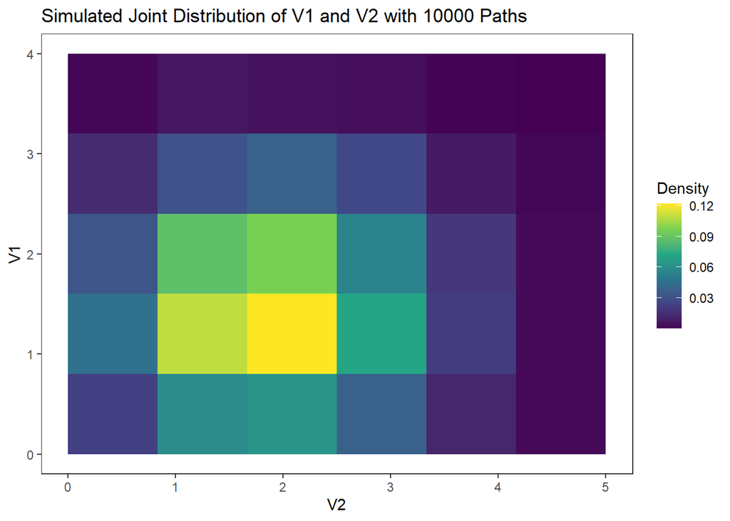

```r
plot_joint_dist(V2_samp, V1, V2)
```

```r
cor(V2_samp$V1, V2_samp$V2)
```

```
[1] 0.01446017
```

> It looks like there is very little linear association between the number of burritos eaten in the first work week and the number of burritos eaten in the second work week.